# Growth_Curve

ikang

2020 12 3

## Drawing growth curves using R

First, you have to set working directory, and then load packages “openxlsx” and “tidyverse”.

```r
setwd("D:/Kin/Protocols/R/R_GrowthCurve2/R_GrowthCurve")
library(openxlsx)
library(tidyverse)
```

## Growth curve without error bars (single tube per each strain)

First, read and save the data from a specific sheet of Excel file.

```r
single <- read.xlsx("Growth.xlsx", sheet="Single")
```

Then, transform the data into tidy form.

```r
single.tidy <- gather(data=single, key=Days, value = Density, -Strain)
```

You can read and transform together by piping with “%>%”.  
If you use piping, the output of the previous command is automatically the input of the next command.

```r
single.tidy <- read.xlsx("Growth.xlsx", sheet="Single") %>%
  gather(key=Days, value = Density, -Strain)
```

Now, plot the data.

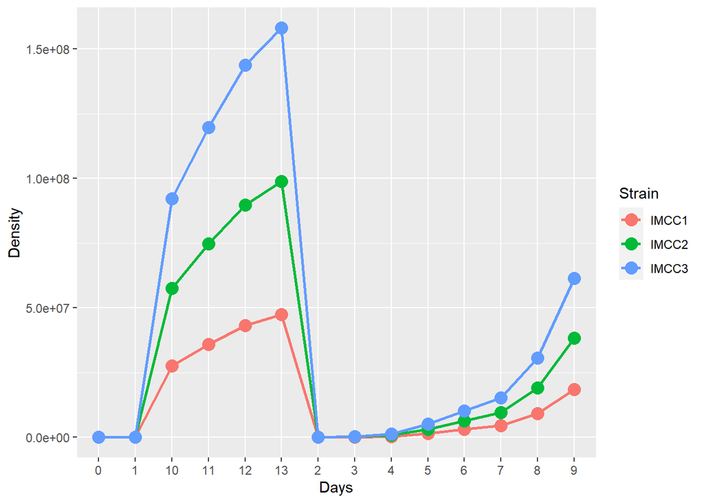

```r
ggplot(single.tidy, aes(x=Days, y=Density, group=Strain, colour=Strain)) +
  geom_line(size=1) + geom_point(size=4)
```

Y-axis of growth curvers usually follows log scale.

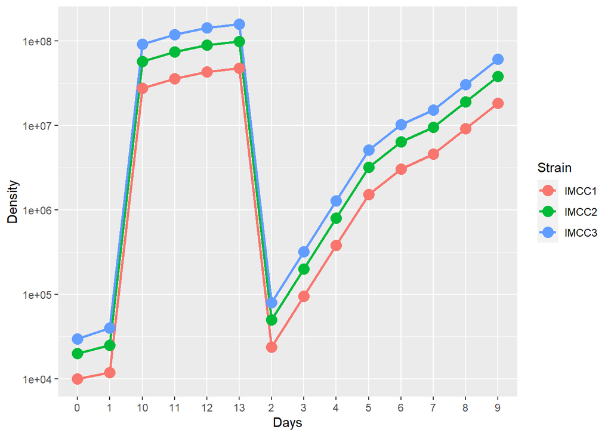

```r
ggplot(single.tidy, aes(x=Days, y=Density, group=Strain, colour=Strain)) +
  geom_line(size=1) + geom_point(size=4) +
  scale_y_log10()
```

“Facet” : One plot for one strain

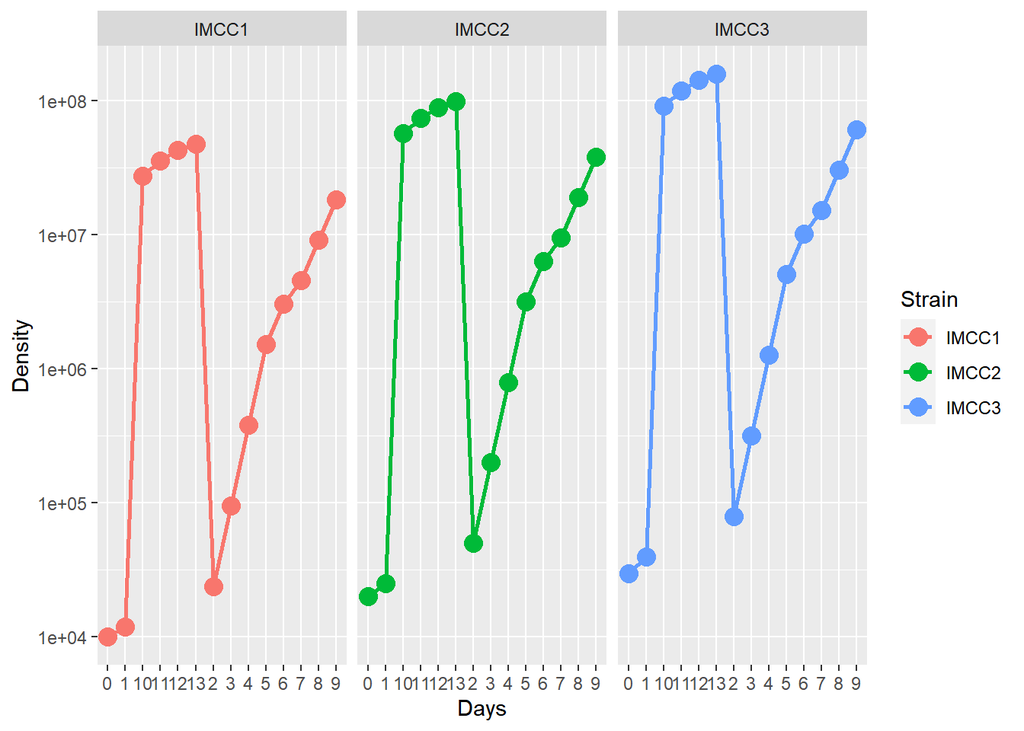

```r
ggplot(single.tidy, aes(x=Days, y=Density, group=Strain, color=Strain)) +
  geom_line(size=1) + geom_point(size=4) +
  scale_y_log10() +
  facet_wrap(~Strain)
```

## Growth curve with error bars (triplicate per each strain)

Read the data and make tidy.

```r
triple <- read.xlsx("Growth.xlsx", sheet="Triplicate")
triple <- gather(data=triple, key=Days, value = Density, -Strain, -Flask)
```

Grouping the data by Strain AND Days: In this case, 3 flasks are grouped per each strain per each day.

```r
triple.gr <- group_by(triple, Strain, Days)
```

Check the result of “grouping”.

```r
triple.gr
```

```
## # A tibble: 99 x 4
## # Groups:   Strain, Days [33]
##    Strain Flask Days  Density
##    <chr>  <dbl> <chr>   <dbl>
##  1 IMCC1      1 0       10000
##  2 IMCC1      2 0       12000
##  3 IMCC1      3 0       14000
##  4 IMCC2      1 0       20000
##  5 IMCC2      2 0       25000
##  6 IMCC2      3 0       30000
##  7 IMCC3      1 0       30000
##  8 IMCC3      2 0       40000
##  9 IMCC3      3 0       50000
## 10 IMCC1      1 1       20000
## # ... with 89 more rows
```

Calculate and save summary stats based on the grouping (i.e. per each strain per each day)

```r
triple.sum <- summarise(triple.gr, repli=n(), avg=mean(Density), sd=sd(Density))
```

In the above, number of replicates -> saved into ‘repli’ column mean -> saved into ‘avg’ column sd (standard deviation) -> saved into ‘sd’ column

All the above steps can be piped as below.

```r
triple.sum <- read.xlsx("Growth.xlsx", sheet="Triplicate") %>%
  gather(key=Days, value = Density, -Strain, -Flask, convert=T) %>%
  group_by(Strain, Days) %>%
  summarise(repli=n(), avg=mean(Density), sd=sd(Density), se=sd(Density)/sqrt(repli))
```

Check the result.

```r
triple.sum
```

```
## # A tibble: 33 x 6
## # Groups:   Strain [3]
##    Strain  Days repli      avg      sd       se
##    <chr>  <int> <int>    <dbl>   <dbl>    <dbl>
##  1 IMCC1      0     3    12000    2000    1155.
##  2 IMCC1      1     3    24000    4000    2309.
##  3 IMCC1      2     3    96000   16000    9238.
##  4 IMCC1      3     3   384000   64000   36950.
##  5 IMCC1      4     3  1536000  256000  147802.
##  6 IMCC1      5     3  3072000  512000  295603.
##  7 IMCC1      6     3  4608000  768000  443405.
##  8 IMCC1      7     3  9216000 1536000  886810.
##  9 IMCC1      8     3 18432000 3072000 1773620.
## 10 IMCC1      9     3 36864000 6144000 3547240.
## # ... with 23 more rows
```

Plot the result. First, without error bar

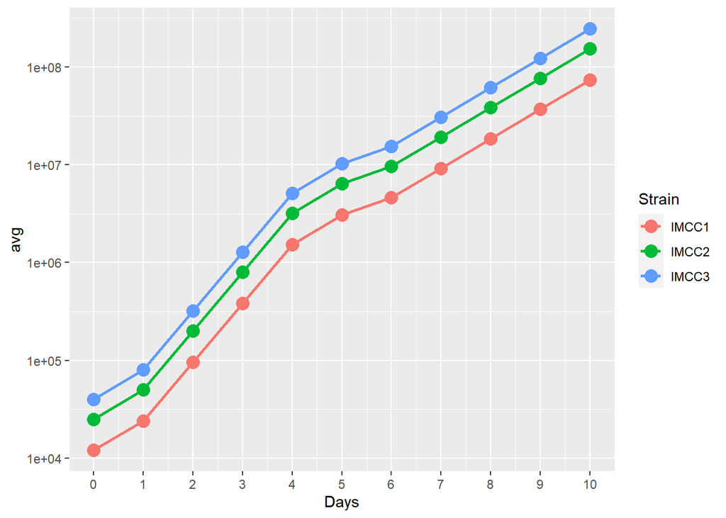

```r
ggplot(triple.sum, aes(x=Days, y=avg, group=Strain, colour=Strain)) +
  geom_line(size=1) + geom_point(size=4) +
  scale_y_log10() +
  scale_x_continuous(breaks=seq(0,10,by=1))
```

Then, with error bar

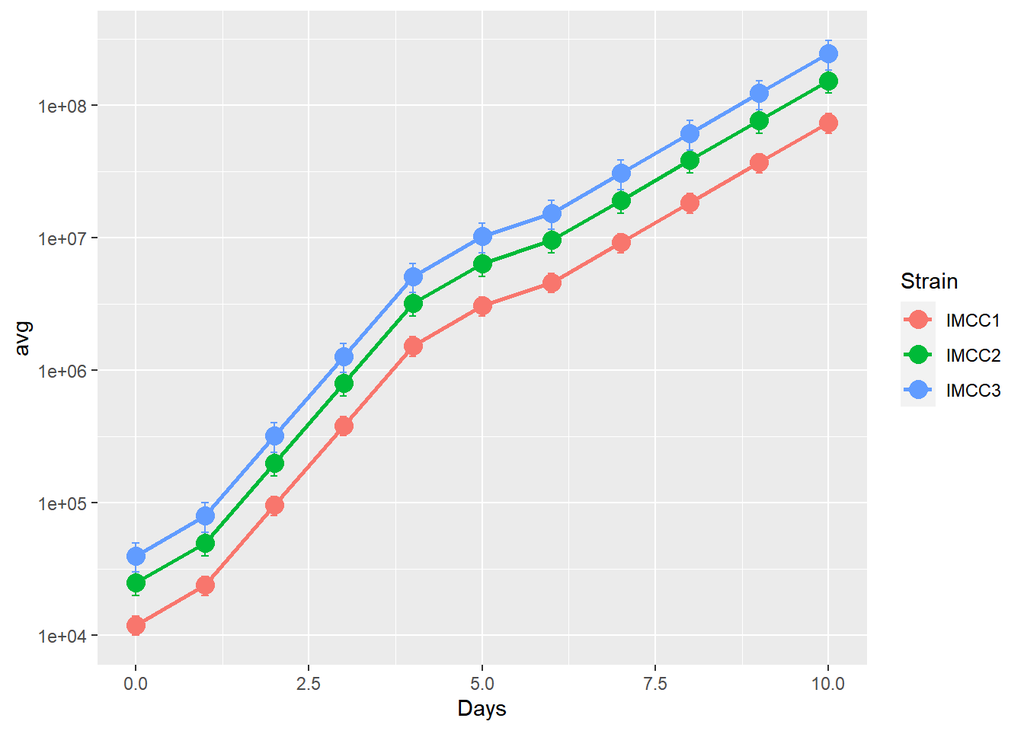

```r
ggplot(triple.sum, aes(x=Days, y=avg, group=Strain, colour=Strain)) +
  geom_line(size=1) + geom_point(size=4) +
  scale_y_log10() +
  geom_errorbar(aes(ymin=avg-sd, ymax=avg+sd), width=0.1, size=0.5)
```

Refine the Y-axis label

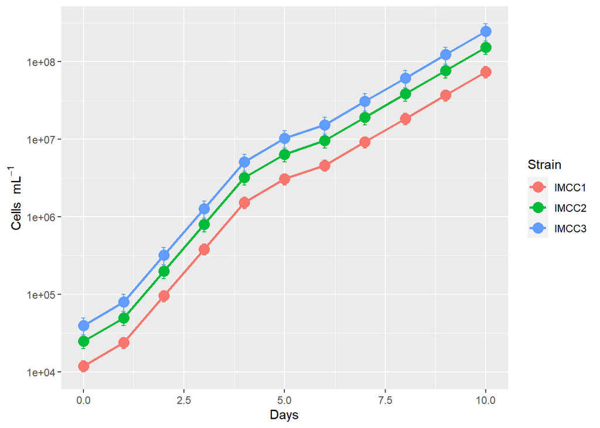

```r
ggplot(triple.sum, aes(x=Days, y=avg, group=Strain, colour=Strain)) +
  geom_line(size=1) + geom_point(size=4) +
  scale_y_log10() +
  geom_errorbar(aes(ymin=avg-sd, ymax=avg+sd), width=0.1, size=0.5) +
  ylab('Cells '~mL^-1)
```

Facet the graph

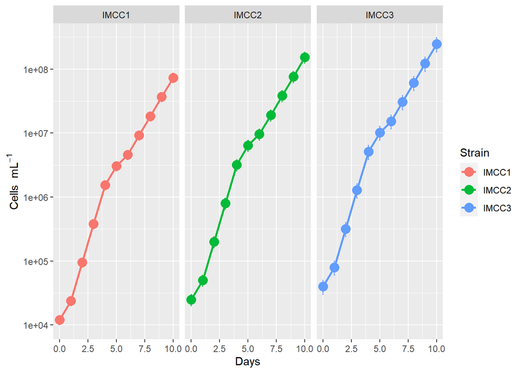

```r
ggplot(triple.sum, aes(x=Days, y=avg, group=Strain, color=Strain)) +
  geom_line(size=1) + geom_point(size=4) +
  scale_y_log10() +
  geom_errorbar(aes(ymin=avg-sd, ymax=avg+sd), width=0.1, size=0.5) +
  ylab('Cells '~mL^-1) +
  facet_wrap(~Strain)
```

Use error ribbon instead of error bar.

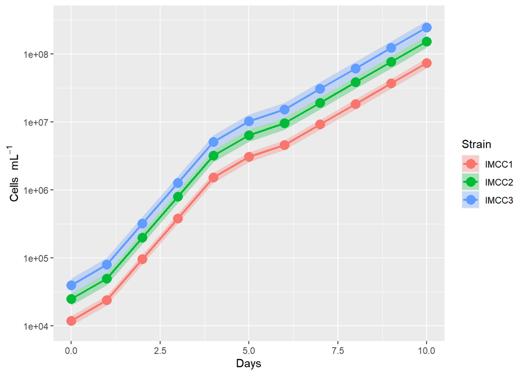

```r
ggplot(triple.sum, aes(x=Days, y=avg, group=Strain, color=Strain)) +
  geom_line(size=1) + geom_point(size=4) +
  scale_y_log10() +
  geom_ribbon(aes(ymin = avg-sd, ymax = avg+sd, fill=Strain), alpha=0.3, linetype=0) +
  ylab('Cells '~mL^-1)
```

Facet with both error bar and error ribbon

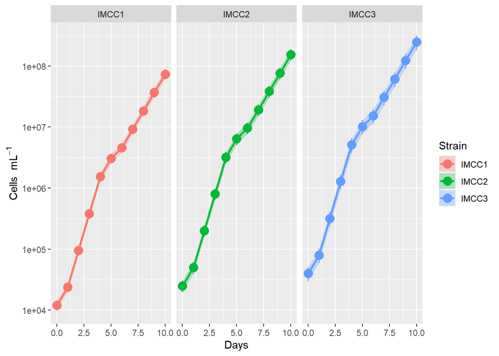

```r
ggplot(triple.sum, aes(x=Days, y=avg, group=Strain, color=Strain)) +
  geom_line(size=1) + geom_point(size=4) +
  scale_y_log10() +
  geom_errorbar(aes(ymin=avg-sd, ymax=avg+sd), width=0.1, size=0.5) +
  geom_ribbon(aes(ymin = avg-sd, ymax = avg+sd, fill=Strain), alpha=0.3, linetype=0) +
  ylab('Cells '~mL^-1) +
  facet_wrap(~Strain)
```